# Gestion_GRA_Clauss

2023-11-23

# 1. Introduction

## Packages

library(tidyverse): The tidyverse package constitutes a collection of R packages meticulously designed to work seamlessly in unison for data manipulation, visualization, and analysis. It encompasses packages like ggplot2 for data visualization, dplyr for data manipulation, tidyr for data tidying, and more. Loading tidyverse avails all these packages for utilization during your R session, streamlining your data analysis workflow.

library(quantmod): The quantmod package primarily caters to quantitative financial modeling and analysis. It furnishes an array of functions and tools for handling financial data, such as downloading and managing stock price data, conducting technical analysis, and modeling financial time series.

library(DataExplorer): The DataExplorer package serves the purpose of preliminary data exploration and analysis. It offers functions to generate summary statistics, visualize missing data, plot variable distributions, and more. It can aid in obtaining a quick overview of your data before delving into more extensive analyses.

library(corrplot): The corrplot package specializes in visualizing correlation matrices. It provides functions for generating visually appealing and informative correlation plots, which prove valuable for comprehending relationships between variables within your data.

library(scales): The scales package provides an assortment of scales and formatting functions tailored for R graphics. It is often employed in conjunction with other plotting packages, such as ggplot2, to customize the appearance of plots, including axes, labels, and color scales.

## Investment universe

In our portfolio management project, we have carefully chosen a set of 20 stocks from a larger universe of investments. This selection represents the most significant companies in the US equity market, primarily based on their market capitalization. By analyzing these stocks, our objective is to gain valuable insights into the strategies that can be employed for managing investments in the US equity market.

Our choice of stocks is guided by several key considerations:

Investment Universe: Our selection is drawn from a universe of stocks that encompasses 20 influential and well-established companies within the US equity market. These companies are known for their substantial market presence and are recognized leaders in their respective industries.

Market Capitalization Focus: We have chosen stocks with an emphasis on market capitalization. Larger market capitalization often indicates stability and lower volatility, making these stocks appealing for various investment strategies.

US Equity Market Perspective: Our project primarily targets insights related to the US equity market. The chosen stocks provide a representative snapshot of the investment landscape in one of the world’s largest and most influential equity markets.

Diversification: To create a well-rounded portfolio, we have ensured diversification across different sectors and industries. Diversification is essential in portfolio management as it spreads risk and mitigates overexposure to a single sector.

Market Visibility: The selected companies are not only well-regarded in the financial sector but are also widely recognized in popular culture. Their performance is closely monitored, and they often hold significant sway over market indices.

Historical Data and Research: These stocks have a rich history of performance data and have been the subject of extensive research. Access to their historical data is abundant, making them suitable for rigorous portfolio management analysis and research.

The provided R code defines the stock tickers for these carefully chosen companies, allowing you to access financial data. This data can then be employed to conduct a range of analyses, such as return calculations, risk assessments, and portfolio optimization, to test and implement various investment strategies on the US equity market.

```r
# Define the stock tickers you want to fetch data for
stock_tickers <- c("AAPL", "MSFT", "GOOGL", "AMZN", "TSLA", "NVDA", "PYPL", "CMCSA", "ADBE", "ASML",
                   "CSCO", "PEP", "AVGO", "TMUS", "INTC", "TXN", "AMGN", "NFLX", "SBUX", "AMAT")
```

## Data cleaning

We perform some formatting to clean the data, an important step in performing data analysis.

Extracting Adjusted Closing Prices: lapply(stock_tickers, function(ticker) { Ad(get(ticker)) }): This code uses the lapply function to retrieve the adjusted closing prices (often used for return calculations) for a list of stock tickers. It iterates through each ticker in the stock_tickers vector and fetches the adjusted closing prices using the Ad() function from the quantmod package.

Combining Stock Returns: do.call(cbind, stock_returns): The code combines the extracted adjusted closing prices into a single data frame by calling cbind (column-bind) on the list of stock returns obtained in the previous step. This creates a data frame where each column represents the adjusted closing prices of a specific stock.

Renaming Columns: colnames(fin_prices) <- stock_tickers: The code assigns the stock tickers as column names to the combined data frame. This step ensures that each column is labeled with the corresponding stock ticker, making it easier to identify each stock’s data.

Handling Missing Data: na.omit(fin_prices): This line of code removes rows with missing values (usually represented as NA) from the combined data frame, fin_prices. Removing missing data is a common preprocessing step to ensure the quality and consistency of the dataset for further analysis.

We perform the arithmetic return method to compute returns for this data set. It is simple, intuitive and widely accessible. Arithmetic returns are particularly useful for performance measurement, providing a clear view of actual gains and losses. It is well-suited for short-term analysis and offer transparency.

From the figure below, Tesla’s stock (TICKER: TSLA) witnessed an unprecedented surge in attraction, making it a notable standout within our investment universe.

Tesla’s performance distinctly outpaced the broader investment universe. The surge in retail trading interest for the electric car company can explain to some extent this massive performance, especially in the wake of the post-COVID market, where intensive monetary policies prompted significant investments from both corporate and retail investors seeking higher yields.

The code allowed us to plot returns into a time series, providing a clear visualization of stock performance during the specified period.

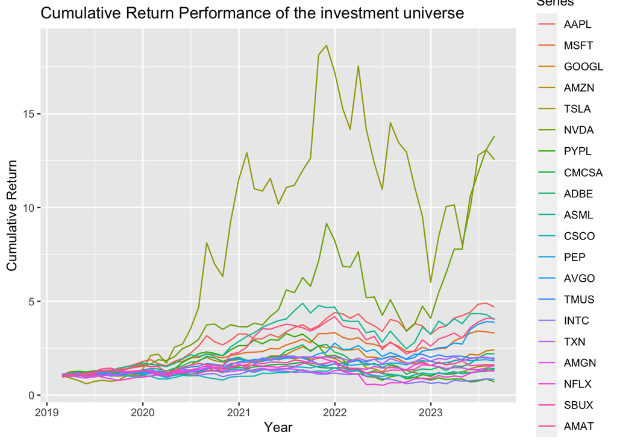

```r
# Calculate Cumulative Returns
cumulative_returns <- cumprod(1 + arith_fin_returns)

# Plot Cumulative Return Performance
library(ggplot2)
autoplot(cumulative_returns, facets = NULL) +
  ggtitle("Cumulative Return Performance of the investment universe") +
  ylab("Cumulative Return") +
  xlab("Year")
```

We can define the minimum volatility portfolio as a portfolio of assets with the lowest possible risk for an investor and is located on the far-left side of the efficient frontier. Note that the minimum volatility portfolio is also called the minimum variance portfolio or more precisely the global minimum volatility portfolio (to distinguish it from other optimal portfolios obtained for higher risk levels).

To implement to global minimum variance portfolio, we need to compute the covariance matrix as an input parameter for the Markowitz optimization model.

```r
cov_matrix <- cov(arith_fin_returns)
```

Correlation plays an important role in a Markowitz allocation framework, where diversification can be achieved when allocating capital to poorly or negatively correlated assets.

The concept of diversification seeks to enhance returns while minimizing risk by investing in a variety of assets that will react differently to the same event (s). For example, whenever there is unfavorable news about a certain event, i.e. 2008 subprime mortgage crisis, the stock market typically declines dramatically. Simultaneously, the same news has generally benefited the price of specific assets, such as gold. As a result, portfolio diversification should include not just diverse stocks inside and outside of the same industry, but also diverse asset classes, such as bonds and commodities. The diversification effect is a term that relates to the link between portfolio correlations and diversification. When there is an imperfect correlation between assets (positive or negative), the diversification effect occurs. It is a critical and successful risk mitigation method since risk mitigation may be accomplished without sacrificing profits. As a result, any prudent investor who is ‘risk cautious’ will diversify to a certain extent.

Here, we observe opportunities for diversification within our investment universe. For instance, we notice that stocks often categorized as defensive plays can serve as effective diversification instruments when combined with more aggressive stocks. In this context, consider Amgen Inc. (TICKER: AMGN) in the healthcare industry, which exhibits a neutral correlation when compared to a stock like Tesla (TICKER: TSLA). Similar logic applies to a stock such as PepsiCo Inc. (TICKER: PEP) in relation to Tesla. It’s worth noting that within our investment universe, we do not find negative correlations, as all the assets exhibit some degree of correlation to one another.

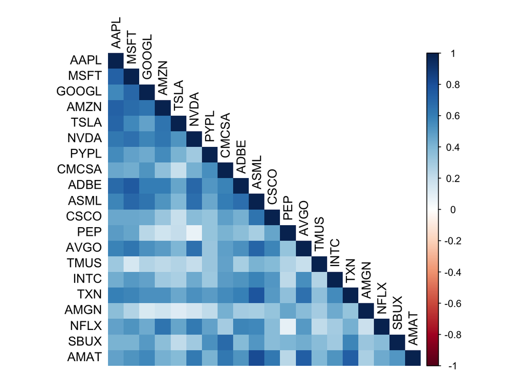

```r
corrplot(cor(arith_fin_returns), type='lower',
         method = "shade", tl.col = 'black', cl.pos = "r", tl.cex = 1)
```

```r
summary(arith_fin_returns)
```

```
##      Index                 AAPL               MSFT              GOOGL
##  Min.   :2019-02-28   Min.   :-0.12421   Min.   :-0.10927   Min.   :-0.17947
##  1st Qu.:2020-04-15   1st Qu.:-0.04700   1st Qu.:-0.01862   1st Qu.:-0.02426
##  Median :2021-05-31   Median : 0.05401   Median : 0.02539   Median : 0.02571
##  Mean   :2021-05-31   Mean   : 0.03221   Mean   : 0.02396   Mean   : 0.01923
##  3rd Qu.:2022-07-15   3rd Qu.: 0.09790   3rd Qu.: 0.06768   3rd Qu.: 0.07187
##  Max.   :2023-08-31   Max.   : 0.21657   Max.   : 0.17629   Max.   : 0.15900
##       AMZN               TSLA               NVDA               PYPL
##  Min.   :-0.23753   Min.   :-0.36733   Min.   :-0.32027   Min.   :-0.3490171
##  1st Qu.:-0.05139   1st Qu.:-0.11275   1st Qu.:-0.01507   1st Qu.:-0.0636589
##  Median : 0.01359   Median : 0.02761   Median : 0.07060   Median : 0.0007901
##  Mean   : 0.01269   Mean   : 0.06937   Mean   : 0.05926   Mean   : 0.0013806
##  3rd Qu.: 0.06707   3rd Qu.: 0.23957   3rd Qu.: 0.15152   3rd Qu.: 0.0799753
##  Max.   : 0.27060   Max.   : 0.74145   Max.   : 0.36344   Max.   : 0.2847295
##      CMCSA                ADBE               ASML               CSCO
##  Min.   :-0.189555   Min.   :-0.26307   Min.   :-0.17424   Min.   :-0.155054
##  1st Qu.:-0.041480   1st Qu.:-0.04637   1st Qu.:-0.03132   1st Qu.:-0.044070
##  Median : 0.019909   Median : 0.02997   Median : 0.03750   Median : 0.006505
##  Mean   : 0.009327   Mean   : 0.01921   Mean   : 0.03068   Mean   : 0.008848
##  3rd Qu.: 0.049657   3rd Qu.: 0.09044   3rd Qu.: 0.10384   3rd Qu.: 0.053772
##  Max.   : 0.189394   Max.   : 0.18960   Max.   : 0.29112   Max.   : 0.198329
##       PEP                AVGO               TMUS                INTC
##  Min.   :-0.08422   Min.   :-0.20967   Min.   :-0.099640   Min.   :-0.202240
##  1st Qu.:-0.01772   1st Qu.:-0.01517   1st Qu.:-0.042477   1st Qu.:-0.050787
##  Median : 0.01320   Median : 0.02889   Median : 0.009378   Median : 0.013973
##  Mean   : 0.01205   Mean   : 0.02892   Mean   : 0.014414   Mean   : 0.001213
##  3rd Qu.: 0.03999   3rd Qu.: 0.07955   3rd Qu.: 0.051989   3rd Qu.: 0.068705
##  Max.   : 0.11221   Max.   : 0.28964   Max.   : 0.213288   Max.   : 0.310469
##       TXN                AMGN                NFLX               SBUX
##  Min.   :-0.13074   Min.   :-0.146443   Min.   :-0.49182   Min.   :-0.17951
##  1st Qu.:-0.04047   1st Qu.:-0.045669   1st Qu.:-0.04679   1st Qu.:-0.03225
##  Median : 0.01563   Median : 0.006209   Median : 0.01753   Median : 0.01534
##  Mean   : 0.01422   Mean   : 0.011018   Mean   : 0.01255   Mean   : 0.01176
##  3rd Qu.: 0.05940   3rd Qu.: 0.046808   3rd Qu.: 0.07322   3rd Qu.: 0.05860
##  Max.   : 0.17194   Max.   : 0.199423   Max.   : 0.28610   Max.   : 0.18706
##       AMAT
##  Min.   :-0.22432
##  1st Qu.:-0.02979
##  Median : 0.04424
##  Mean   : 0.03189
##  3rd Qu.: 0.08428
##  Max.   : 0.39667
```

In portfolio management, statistical analysis can help understand financial patterns in data.

First, density plots, also known as probability density function plots, serve the purpose of visualizing data distributions. They offer insights into the shape, spread, and central tendencies of data, making them crucial for assessing the nature of financial asset returns.

Second, QQ plots, or quantile-quantile plots, are utilized to evaluate whether a dataset adheres to a specific theoretical distribution, such as the normal distribution. These plots help portfolio managers identify departures from expected distributions, facilitating informed investment decisions. Together, these techniques aid in the exploration and assessment of financial data, enabling portfolio managers to make more informed and data-driven choices in their investment strategies.

We can run some more advanced statistical analysis to understand the asset return behavior of the equities selected in this analysis.

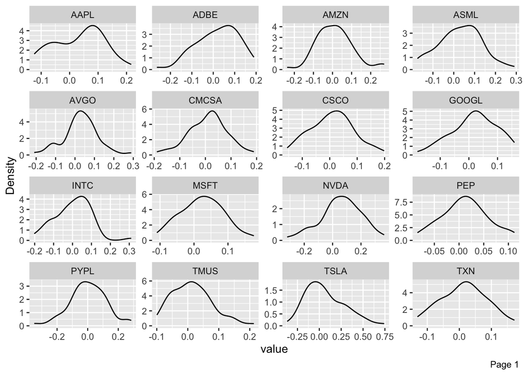

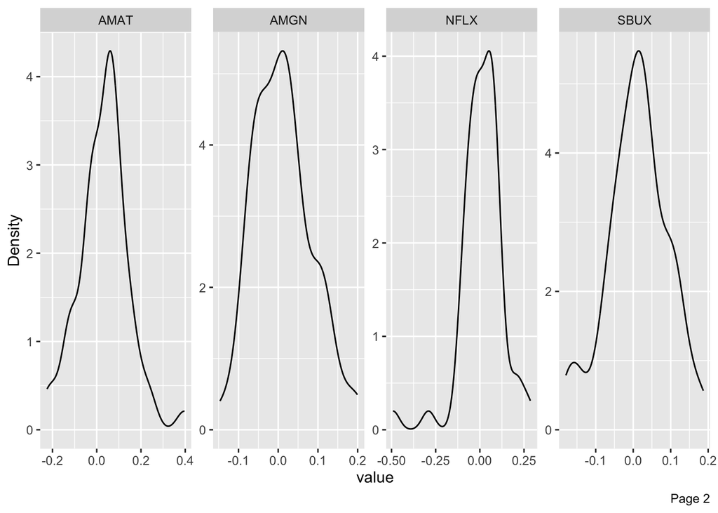

```r
plot_density(arith_fin_returns)
```

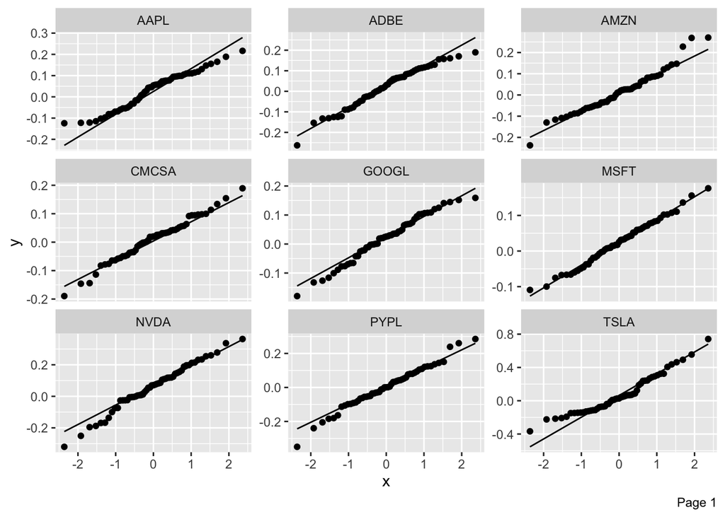

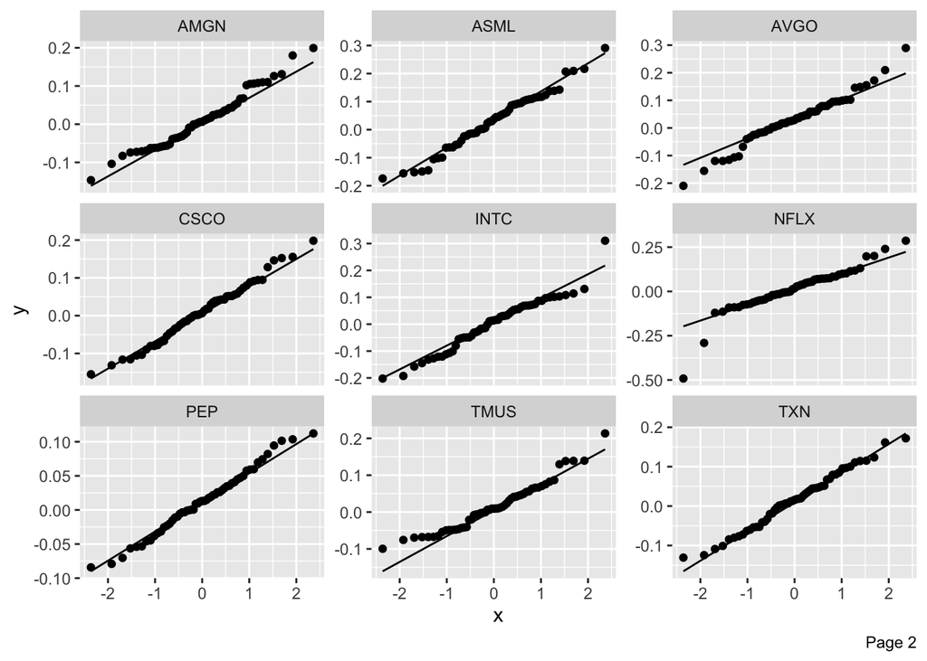

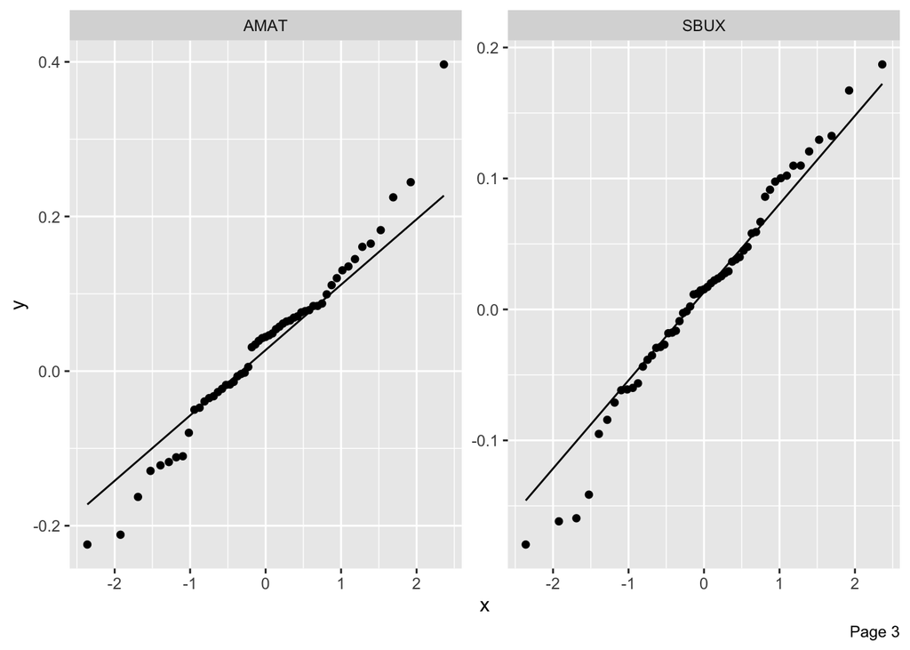

```r
plot_qq(arith_fin_returns)
```

# 2. Modelling part

Modern Portfolio Theory (MPT) is founded on several market and investor assumptions. Several of these assumptions are stated explicitly, while others are implied. Markowitz's contributions to (MPT) in portfolio selection are based on the following basic assumptions:

- Investors are rational (they seek to maximize returns while minimizing risk, or minimize risk while maximize return).
- Investors will accept increased risk only if compensated with higher expected returns.
- Investors receive all relevant information regarding their investment decision.
- Investors can borrow or lend an unlimited amount of capital at a risk-free rate of interest.

## Unbiased Global Minimum Variance (GMV) portfolio

In the context of time series data analysis, one of the crucial applications is the division of the data set into a training set and a testing set based on temporal order. This approach is particularly important when dealing with data that evolves over time, such as stock prices, weather observations, or economic indicators.

The training set typically comprises historical data, while the testing set contains more recent observations. This temporal separation allows for the evaluation of predictive models and forecasting techniques. By using historical data to train the model and then assessing its performance on more recent data, analysts can gauge the model’s ability to make accurate predictions and anticipate future trends. Time series data applications are essential in fields like finance, where understanding and forecasting trends over time is important.

For the purpose of modelling, we will shrink the data set into two different sub-samples. We can define the following parameters:

1. The first sub-sample will cover the first 20 trading month covered in the data set.

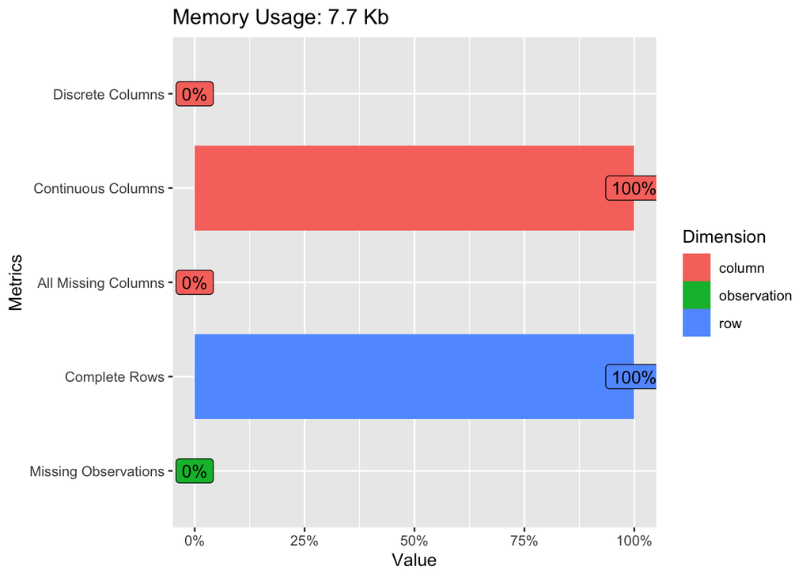

2. The second sub-sample will cover the rest of the data set, covering the equivalent of 36 trading month.

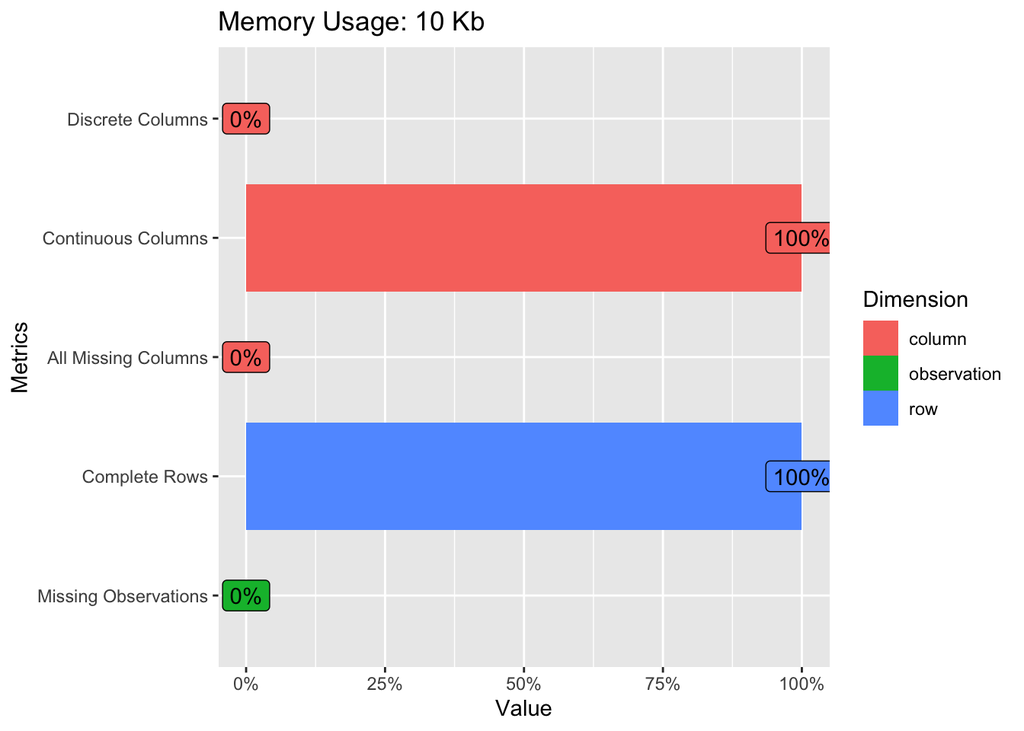

We implement the parameters of the model in order to compute the GMV:

After computing the parameters required to implement the unbiased GMV portfolio, we can compute omega, representing the weightings of the portfolio as follows.

We can see in this instance that the portfolio is mixed, with some long and short positions. The capital is fully invested, with some important exposure in the long part of the portfolio on stocks like Adobe (TICKER: ADBE) with 94.61%, followed by PepsiCo (TICKER: PEP) at 73.15%. and T-Mobile (TICKER: TMUS) at 55.69%.

On the short part of the portfolio, we can see an important short on three stocks that can stand out: Microsoft (TICKER: MSFT) -49.83%, ASML corporation (TICKER: ASML) at -43.22% and Paypal (TICKER: PYPL) at -40.79%.

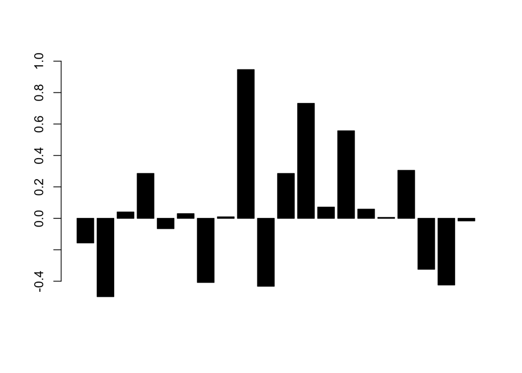

## Implementation of Principal Component Analysis (PCA)

PCA can be used for a variety of tasks, including dimensionality reduction, data visualization, and feature extraction. In the context of portfolio management, PCA can be used to:

- Identify the underlying factors that drive the returns of the stocks in the portfolio.
- Construct more diversified portfolios by selecting stocks with low correlations with each other.
- Reduce the dimensionality of the portfolio by selecting the most important principal components.

The below plot represents the portfolio allocation using the PCA method.

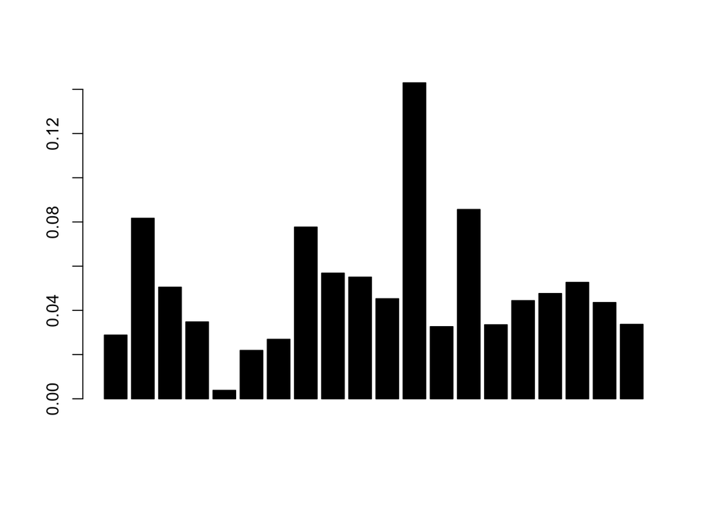